# Alfonso Andres Time Series Project

Alfonso Andres

2023-07-10

## Introduction

This project involves fitting various time series models to multiple datasets to explore patterns and predict complex outcomes. We will work with six distinct datasets, analyzing each using different time series methodologies. By comparing the results, we will highlight the strengths and weaknesses of each approach in time series analysis.

First of all show all the libraries to we will use in this project. Most of them have been seen in class

```r
library('ggfortify')
```

```r
library('ggplot2')
library('stats')
library("dlm")
library('forecast')
library('bsts')
library('nnet')
```

## Part 1: Alcoa Stocks

In this analysis, we use the dataset aa-rv-20m.txt, which contains the realized daily volatility series of Alcoa stock returns. The data spans from January 2, 2003, to May 7, 2004, and is based on 20-minute intraday log returns. The primary goal is to model and analyze the log-transformed volatility series using two different approaches. After calling the necessary libraries. We open the dataset as a csv file and plot the Alcoa stocks as a Time series with no seasonal component.

We fit the ARIMA(0,1,1) model to our data, and plot fitted values as the observed values plus the residuals that have just been obtained from the process. It is known that the ARIMA(0,1,1), as every other ARIMA process, is equivalent to a state-space model with the following equation: $y_{t}=\mu_{t}-\epsilon{t} \;\;\; \epsilon\sim N(0,\sigma_{\epsilon})$ $\mu_{t+1}=\mu_{t}+ \eta{t}\;\;\; \eta\sim N(0,\sigma_{\eta})$

We plot the fitted value and see a significant different in the fitted values from the model than in the observed. We are now going to see whethere the the residuals follow a normal distribution and also the goodness of fit

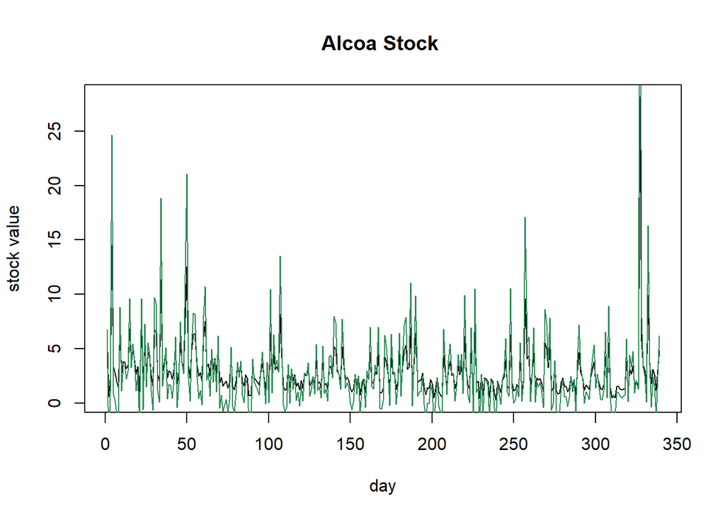

```r
www <- 'https://www.mimuw.edu.pl/~noble/courses/TimeSeries/data/aa-rv-20m.txt'
df1 <- read.csv(www)
dfts <- ts(df1)
arimadf <- arima(dfts,order = c(0,1,1))
plot(dfts, ylab = 'stock value', xlab = 'day',mai = 'Alcoa Stock ')
lines(arimadf$residuals+dfts,col = 'seagreen')
```

As we can see residuals do not follow a normal distribution judging this qq plot.

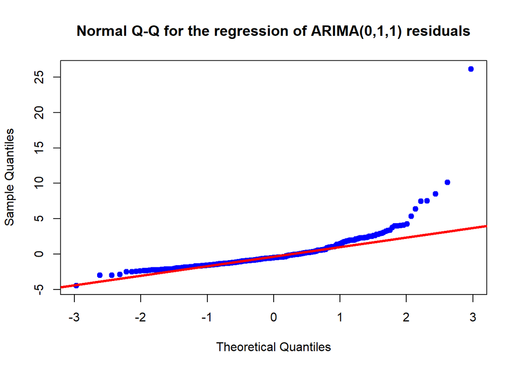

```r
qqnorm(arimadf$residuals,col='blue',pch = 19,main = 'Normal Q-Q for the regression of ARIMA(0,1,1) residuals')
qqline(arimadf$residuals,col ='red',lwd=3)
```

Interpreting the AIC we can see that is not a really explicative model for our data since by the AIC criterion our value is really high. We see that the mean is relatively low compared to the logarithmic values of our dataset. However the variance is extremely high and so the value vary abrouptly and the fit of the model is not too good

```r
cat(var(arimadf$residuals),mean(arimadf$residuals),arimadf$aic)
```

```
## 5.198709 -0.04892031 1522.718
```

```r
structure <-StructTS(dfts,type = 'level')
structure$coef
```

```
##      level    epsilon
## 0.01700797 4.90368471
```

We now plot the filtered and smoothed variables with 95% pointwise confidence interval. The scatter plot does not give a clear outcome since the amount of data is big and there scatter is all piled up.However we see that in both cases the filtered and smoothed data is generally closer to 0 than the observed, so there is lower presence of outliers. The confidence interval is not too big either so it is a good estimation taking into account that the innovation variance for either case and time period is almost constant and subsequently small.

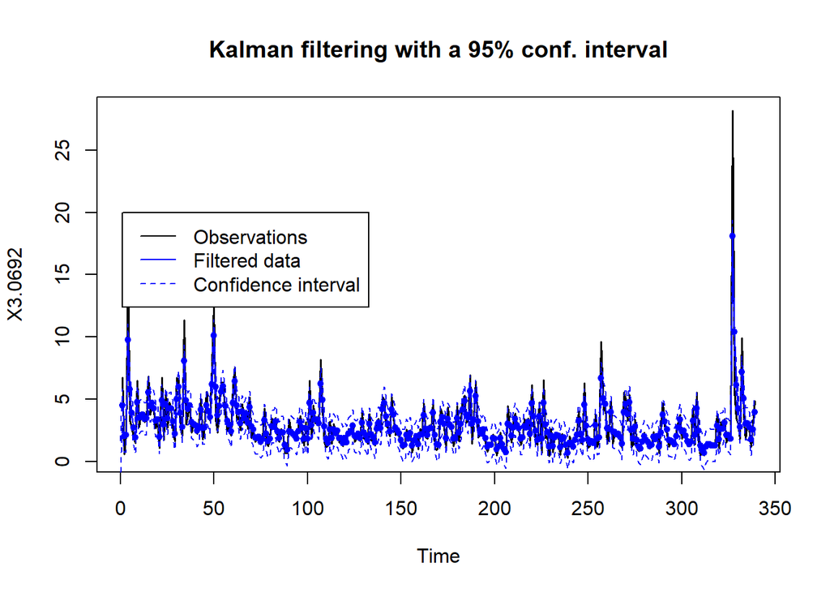

```r
modi <-dlmModPoly(1)
modi$C0<-1
stockfilter <- dlmFilter(dfts,modi)
stocksmoother<- dlmSmooth(dfts, modi)
plot(dfts,type = 'l', col = 'black',lwd = 1.9, main ='Kalman filtering with a 95% conf. interval')
lines(dropFirst(stockfilter$m), type = 'o', pch = 20, col = "blue")
attach(stockfilter)
v <- unlist(dlmSvd2var(U.C, D.C))
pl <-  stockfilter$m + qnorm(0.05, sd = sqrt(v))
pu <-    stockfilter$m + qnorm(0.95, sd = sqrt(v))
detach(stockfilter)
lines(pl, lty = 2, col = "blue")
lines(pu, lty = 2, col = "blue")
legend(1,20,legend=c('Observations','Filtered data','Confidence interval'),
       col =c('black','blue','blue'),lty =c(1,1,2))
```

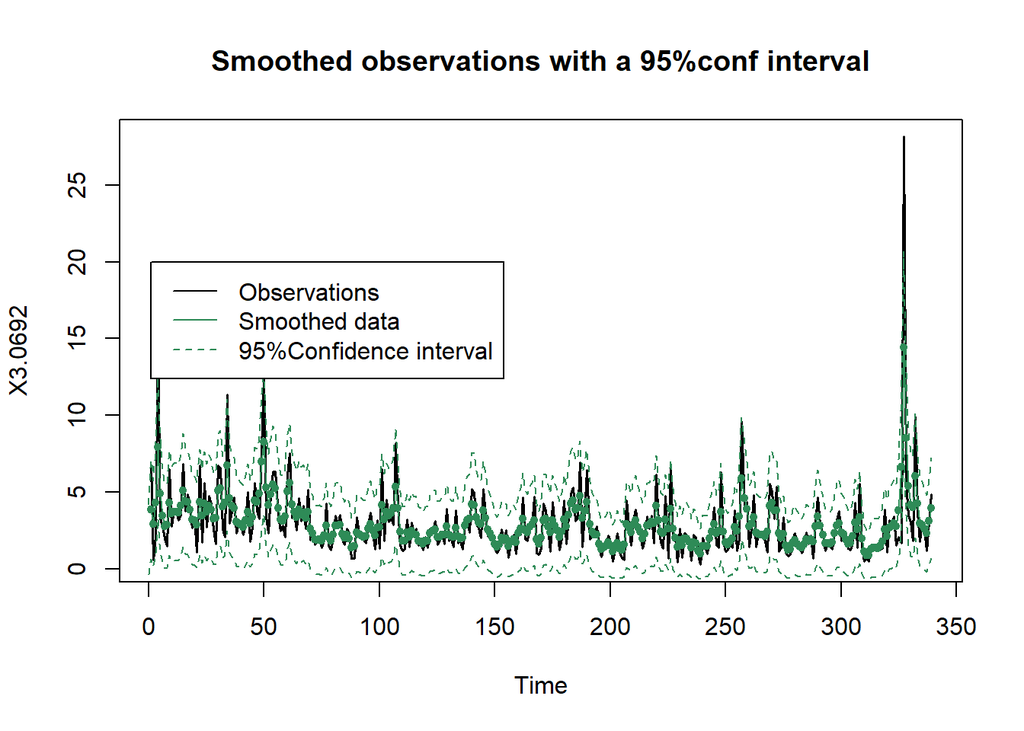

```r
plot(dfts,type = 'l', col = 'black',lwd = 1.9,
     main ='Smoothed observations with a 95%conf interval')

lines(dropFirst(stocksmoother$s), type = 'o', pch = 20, col = "seagreen")
attach(stocksmoother)
sl <-  stocksmoother$s + qnorm(0.05, sd = sqrt(s))
su <-  stocksmoother$s +qnorm(0.95, sd = sqrt(s))
detach()
lines(sl, lty = 2, col = "seagreen")
lines(su, lty = 2, col = "seagreen")
legend(1,20,legend=c('Observations','Smoothed data','95%Confidence interval'),
       col =c('black','seagreen','seagreen'),lty =c(1,1,2))
```

## Part 2: Pfizer data

In this part we wil use monthly simple excess returns of Pfizer stock and the S&P 500 composite index from January 1990 to December 2003. The excess returns are in m-pfesp-ex9003.txt with Pfizer stock returns in the first column.

First we open our data and plot both columns. Pfizer stocks and S&P 500 returns. The data spreads evenly around the values $[-0.1,0.1]$ for the Pfizer stocks and $[-0.10,0.10]$ in the other column, with a couple of outliers in either case.

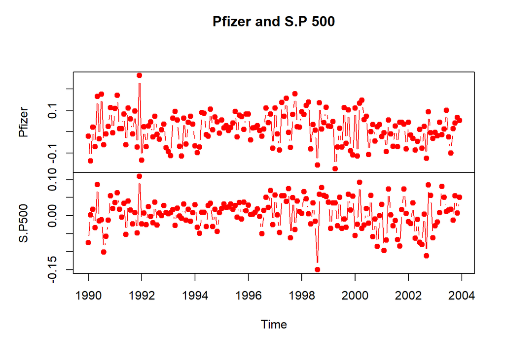

```r
www1 <- 'https://www.mimuw.edu.pl/~noble/courses/TimeSeries/data/m-pfesp-ex9003.txt'
names <-c('Pfizer','S&P500')
pfizer <- read.csv(www1,sep = '',header = FALSE,col.names = names)
pfizerts<-ts(pfizer,frequency = 12,start = 1990)
plot(pfizerts,type = 'b', col= c('red'),pch = 19, main= 'Pfizer and S.P 500')
```

For a constant coefficient model we are going to fit an ARIMA(p,q,d) and fit the Pfizer returns. With the auto.arima function we can see for what values the observed data gets a best fit and check the goodness of fit. In this case we see that the best option is an ARIMA(0,0,1) this is equivalent to a MA(1) process. Where the equation is $y_{t} = + + *{1}* {t-1} $ The outcome of the coefficients are $\mu = 0.0158 \;\;\; \theta_{1} = -0.1035$ We see that the AIC criterion is low by our standards, but we will check further if the model is indeed good. Judging by the RMSE of the training set the model is very descriptive. Values of the ME are also low which gives a good outcome in various criterion so the model is successfully fitted

```r
autopfizer <-auto.arima(pfizer$Pfizer)
autopfizer
```

```
## Series: pfizer$Pfizer
## ARIMA(0,0,1) with non-zero mean
##
## Coefficients:
##           ma1    mean
##       -0.1035  0.0158
## s.e.   0.0708  0.0052
##
## sigma^2 = 0.00571:  log likelihood = 196.53
## AIC=-387.05   AICc=-386.9   BIC=-377.68
```

```r
summary(autopfizer)
```

```
## Series: pfizer$Pfizer
## ARIMA(0,0,1) with non-zero mean
##
## Coefficients:
##           ma1    mean
##       -0.1035  0.0158
## s.e.   0.0708  0.0052
##
## sigma^2 = 0.00571:  log likelihood = 196.53
## AIC=-387.05   AICc=-386.9   BIC=-377.68
##
## Training set error measures:
##                         ME      RMSE        MAE      MPE     MAPE      MASE
## Training set -3.362498e-05 0.0751129 0.05915185 298.0052 311.8624 0.6644371
##                      ACF1
## Training set -0.009935353
```

However when plotting the fitted model vs the initially observed data we can see a much higher variance in the ARIMA(0,0,1) process. Still the fit is more than acceptable and the study is successful.

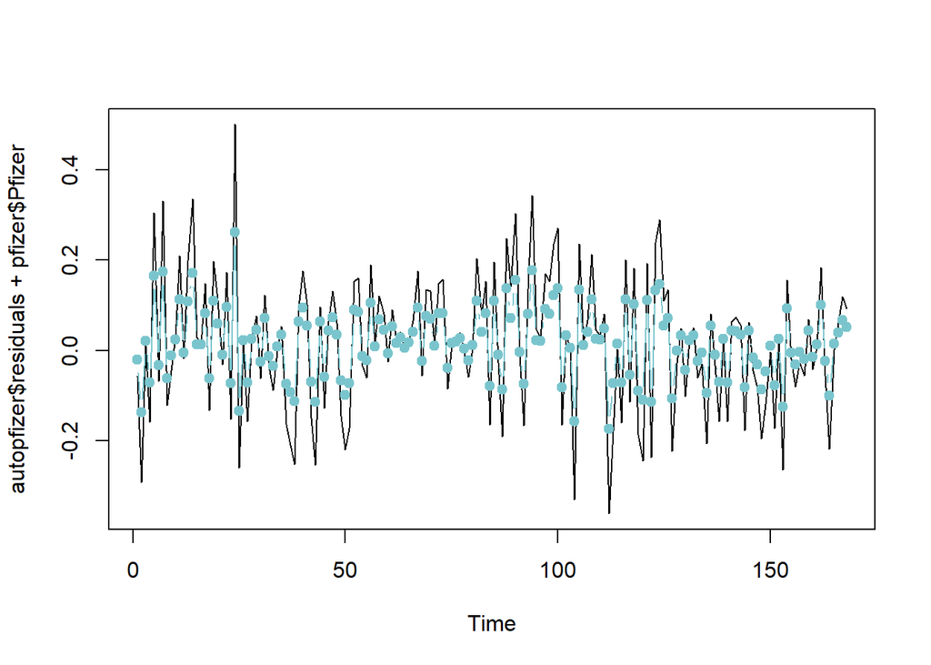

```r
plot(autopfizer$residuals + pfizer$Pfizer)
lines(pfizer$Pfizer, col = 'cadetblue3',type = 'b',pch = 19)
```

Now we will fit a state-space model to our data. $y_{t}=F_{t}\mu_{t}+V_{t}\epsilon{t} \;\;\; \epsilon\sim N(0,\sigma_{\epsilon})$ $\mu_{t+1}=G_{t}\mu_{t}+ W_{t}\eta{t}\;\;\; \eta\sim N(0,\sigma_{\eta})$ In this particular case we fit the model with the following parameters : $V_{t},W_{t} = 1 \;\; t \in 1,2,....,n$ $G_{t},F_{t},W_{t} = I$ I being the identity matrix. So our equation system looks like this a CAPM model that we can fit. After fitting the model we get the innovation variances for each different time. As we see there is not many variations either in the smoothed data or the variances themselves since they are all pretty much the same value. We also plotted the smoothed data for all the $\alpha_{t} \;\;\;and\;\;\;\beta_{t}$. We see that the $\alpha$ takes much more plain values in comparison to our other state variable. Our observed data varies unevenly along the axis similarly to $\beta$

```r
CAPM <-dlmModPoly(2)
CAPM$FF<-CAPM$GG<-CAPM$W<-diag(2)
reg <-dlmSmooth(pfizer$Pfizer,CAPM)
reg$D.S
```

```
##               [,1]         [,2]
##  [1,] 1.272020e+00 1.000000e+00
##  [2,] 7.861514e-01 1.490116e-07
##  [3,] 6.871215e-01 1.490116e-07
##  [4,] 6.714534e-01 1.490116e-07
##  [5,] 6.691368e-01 1.490116e-07
##  [6,] 6.687982e-01 1.490116e-07
##  [7,] 6.687487e-01 1.490116e-07
##  [8,] 6.687415e-01 1.490116e-07
##  [9,] 6.687405e-01 1.490116e-07
## [10,] 6.687403e-01 1.490116e-07
## [11,] 6.687403e-01 1.490116e-07
## [12,] 6.687403e-01 1.490116e-07
## [13,] 6.687403e-01 1.490116e-07
## [14,] 6.687403e-01 1.490116e-07
```

[output cut: 71 more lines]

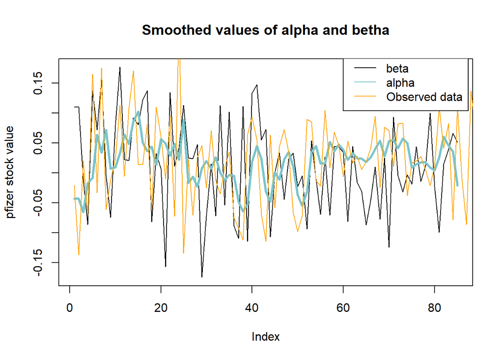

```r
plot(reg$s[,2],main = 'Smoothed values of alpha and betha',type = 'l', ylab = 'pfizer stock value')
lines(reg$s[,1], col = 'cadetblue3', lwd = 3)
lines(pfizer$Pfizer,col = 'orange')
legend(60,0.20,c('beta','alpha','Observed data'),col =c('black','cadetblue3','orange'),lty =c(1,1,1))
```

## Part 3: U.S PPI index

The file “m-ppiaco4709.txt” contains year, month, day, and U.S. producer price index (PPI) from January 1947 to November 2009 that we will use to fit our AR(p) model We proceed to the reading and processing of our data. First take the observed data $Z_{t}\;\;\;t\in{1,2,3,....,n}$ and transform it first by doing $z_{t} = ln(Z_{t})-ln(Z_{t-1})$ and then by centering all the data on the mean by $y_{t} = z_{t}-\hat{z_{t}}$

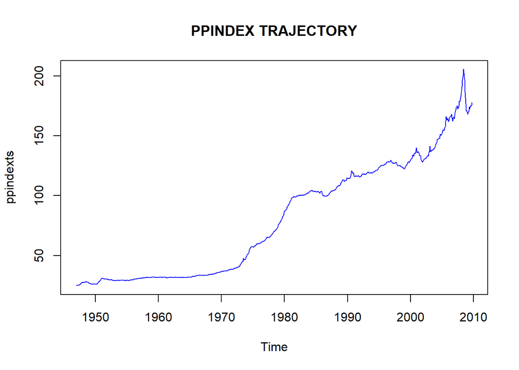

```r
ww2 = 'https://www.mimuw.edu.pl/~noble/courses/TimeSeries/data/m-ppiaco4709.txt'
ppindex <- read.csv(ww2,sep = '', col.names = c('year','month','day','ppi'))
ppindexts <-ts(ppindex$ppi,frequency = 12, start = 1947)
plot(ppindexts,pch = 20, type = 'l', main = 'PPINDEX TRAJECTORY')
lines(ppindexts,col = 'blue')
ppindexlog<-diff(log(ppindexts))
ppindexlog2<-diff(log(ppindex$ppi))
meanppi <- mean(ppindexlog2)
lines(ppindexlog)
```

```r
yt  <-ppindexlog-meanppi
```

We see a clear difference in the trajectory of both variables, basically because one is focused on the variance in comparison to the previous year and the other in the trajectory through out the last 60 years of the PP index.

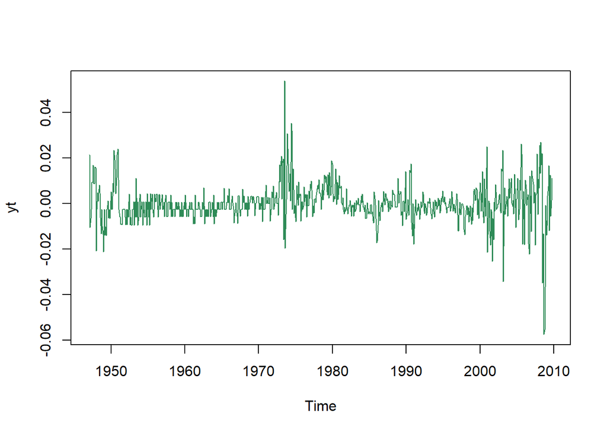

```r
plot(yt,col ='seagreen')
```

Now we fit the model that was asked in the exercise, an AR(3) model to fit the data. Already knowing that all AR(p) models can b expressed as state-space model we could also fit this model using the dlm package (which we will do after). We check the AIC criterion and the outcome is not too good, however our coefficients are not too high and the RMSE is low still which could mean that the model is well fiutted for our tranformed data $y_{t}$. Also the ME of our training set seems low another indicative of a good AR(3).

```r
arimayt<- arima(yt,order = c(3,0,0))
summary(arimayt)
```

```
##
## Call:
## arima(x = yt, order = c(3, 0, 0))
##
## Coefficients:
##          ar1     ar2     ar3  intercept
##       0.2866  0.1231  0.0905      0e+00
## s.e.  0.0366  0.0378  0.0366      6e-04
##
## sigma^2 estimated as 6.131e-05:  log likelihood = 2583.32,  aic = -5156.64
##
## Training set error measures:
##                        ME        RMSE         MAE       MPE     MAPE      MASE
## Training set -1.47322e-05 0.007830141 0.005066477 -99.44483 351.1487 0.8378293
##                      ACF1
## Training set -0.002620595
```

We see that the AR(3) model distances a little from our observed data, however the same happened in the previous exercise and the process was highly significant

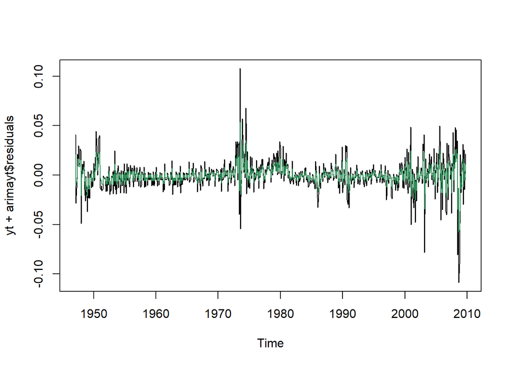

```r
plot(yt + arimayt$residuals)
lines(yt, col='seagreen')
```

The variance and mean of the errors are low. $Y_{t}$ had 0 mean which means that a good fit would have something really close to 0, also the variance of the residuals is low which means that they do not fall to far off of their mean.

```r
cat(var(arimayt$residuals),mean(arimayt$residuals))
```

```
## 6.139243e-05 -1.47322e-05
```

To use a state space form to estimate the parameters with the observation equation as: $y_{t}= x_{t} + \epsilon{t} \;\;\; \epsilon\sim N(0,\sigma_{\epsilon})\;$. Knowing that $x_{t}$ is an AR(3) model, we have to carve the space state equations to fit the model

First of all the general space-state equations are: $y_{t}= F{t} \alpha_{t} + S_{t}\epsilon{t} \;\;\; \epsilon{t}\sim N(0,\sigma_{\epsilon})\;$ $\alpha_{t+1}= G{t} \alpha_{t} + V_{t}\nu{t} \;\;\; \nu_{t}\sim N(0,\sigma_{\nu})\;$ In this case we have to transform G into a $I_{3}$ matrix in order to fit the model all other parameters stay the same i.e $F_{t},S_{t},V_{t} = 1$. Therefore our final equation shapes like : $y_{t}= F{t} \alpha_{t} + S_{t}\epsilon{t} \;\;\; \epsilon{t}\sim N(0,\sigma_{\epsilon})\;$ $\alpha_{t+1}= \theta_{1}\alpha_{t} +\theta_{2}\alpha_{t-1}+\theta_{3}\alpha_{t-2} + \nu{t} \;\;\; \nu_{t}\sim N(0,\sigma_{\nu})\;$ Becoming the measurement equation into an AR(3) process. We can either fit every constant $\theta_{i}$ or have them take the previously fitted AR(3) coefficients

```r
mod3<-dlmModPoly(1)
mod3$GG<-c(vector <- c(2.865738e-01, 1.230560e-01, 9.048862e-02))
mod3
```

```
## $FF
##      [,1]
## [1,]    1
##
## $V
##      [,1]
## [1,]    1
##
## $GG
## [1] 0.28657380 0.12305600 0.09048862
##
## $W
##      [,1]
## [1,]    1
##
## $m0
## [1] 0
##
## $C0
##       [,1]
## [1,] 1e+07
```

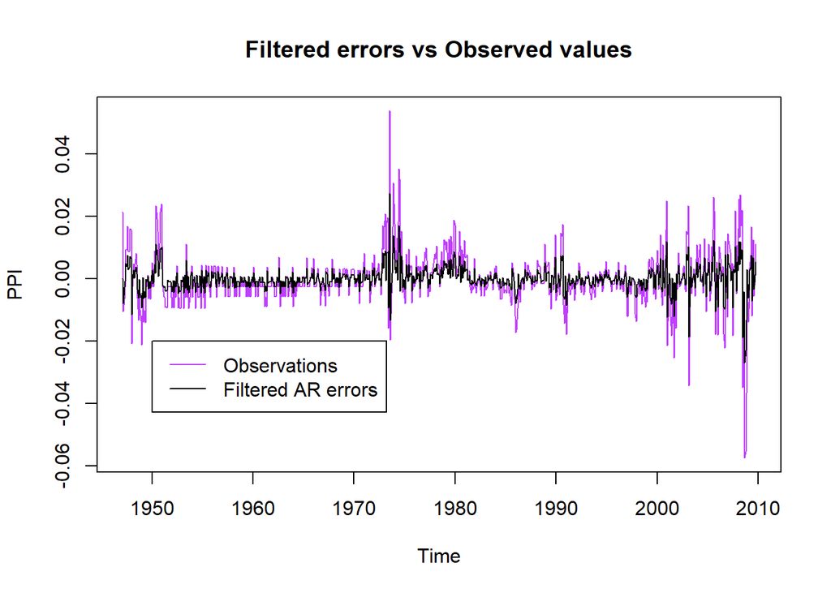

```r
prodfilter <-dlmFilter(yt,mod3)
prodsmoothed<-dlmSmooth(yt,mod3)

error <- yt-prodfilter$m

plot(yt,type='l',col = 'darkorchid1', main = 'Filtered errors vs Observed values', ylab = 'PPI', xlab = 'Time')
lines(error)
legend(1950,-0.02,,legend=c('Observations','Filtered AR errors'),
       col =c('darkorchid1','black'),lty=c(1,1))
```

When plotting the errors we see a clear resemblance to the observed data, it is because indirectly the filtered schema is indeed similar to the PPI index. We plot them together to see a comparison. The errors take much lower values as it was expected, since the filtered schema usually has a much more plain graph and fitness than the original observed sample We also plot the innovation variances of the fitted model and they are constant, none of them surpass 1 and most are stuck at 0.8451779

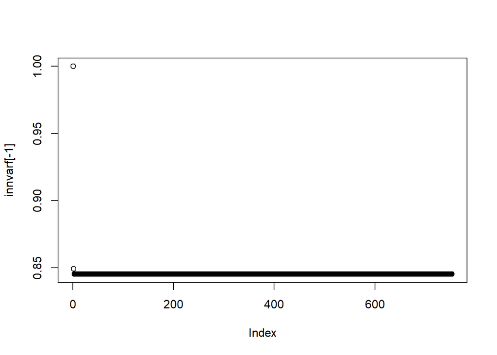

```r
innvarf <- sqrt(prodfilter$D.C)
plot(innvarf[-1])
```

We get the sample variance $\hat{\sigma_{\epsilon}}$, an estimation of $\sigma_{\epsilon}=1.566156e-05$. Very low so the estimation seems decent.

```r
var(error)
```

```
## [1] 1.566156e-05
```

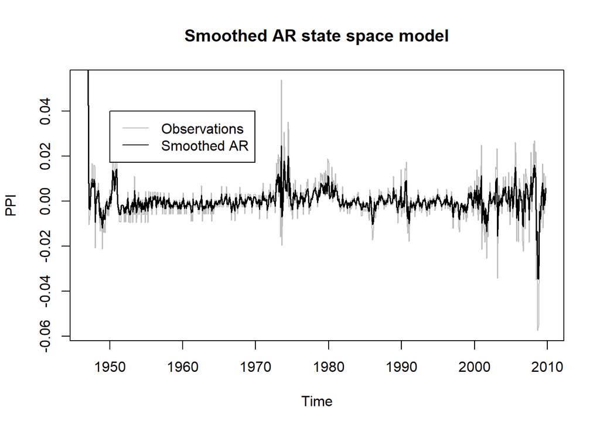

```r
plot(yt, main ='Smoothed AR state space model',col = 'grey',ylab = 'PPI', xlab = 'Time')
lines(prodsmoothed$s,type='l',col = 'black',lwd = 1.9,,pch = 20)
legend(1950,0.04,,legend=c('Observations','Smoothed AR'),
       col =c('grey','black'),lty=c(1,1))
```

## Part 4: IBM stocks data

We now consider the simple returns of IBM stock, CRSP value-weighted index, CRSP equal-weighted index, and the S&P composite index from January 1980 to December 2008. After opening and checking the data, the exercise asks to perform a simple regression to see the effect of weekday trading at 5% confidence level. I opted on using a simple regression function ‘lm’ and making the dependent variables every day of the week that appears. Apparently when we fit the regression we can see that the most significant days are Monday.Tuesday and Friday, Thursday does not seem to appear due to the fact that it is linearly related to the other days of the week. Therefore the most important values seem to be those. The low p-value return infers that there is indeed evidence to reject the null hypothesis, so therefore there is significance in the relation of the weekday to the EW return.

```r
ww3 = 'https://www.mimuw.edu.pl/~noble/courses/TimeSeries/data/d-ibm3dxwkdays8008.txt'
ibmm<-read.csv(ww3,header = TRUE,sep = '',
               col.names = c('year', 'mom','day','ibm','vw','ew', 'sp', 'm','t','w','r' ,'f'))
regression<-lm(formula = ew ~ m+t+w+f+r,,data = ibmm)
summary(regression)
```

```
##
## Call:
## lm(formula = ew ~ m + t + w + f + r, data = ibmm)
##
## Residuals:
##       Min        1Q    Median        3Q       Max
## -0.102962 -0.003094  0.000533  0.003795  0.108319
##
## Coefficients: (1 not defined because of singularities)
##               Estimate Std. Error t value Pr(>|t|)
## (Intercept)  0.0012092  0.0002148   5.631 1.86e-08 ***
## m           -0.0021440  0.0003080  -6.961 3.67e-12 ***
## t           -0.0009484  0.0003023  -3.137 0.001711 **
## w            0.0000109  0.0003022   0.036 0.971239
## f            0.0010294  0.0003042   3.384 0.000719 ***
## r                   NA         NA      NA       NA
## ---
## Signif. codes:  0 '***' 0.001 '**' 0.01 '*' 0.05 '.' 0.1 ' ' 1
##
## Residual standard error: 0.008234 on 7314 degrees of freedom
## Multiple R-squared:  0.01618,    Adjusted R-squared:  0.01564
## F-statistic: 30.06 on 4 and 7314 DF,  p-value: < 2.2e-16
```

We check the ACF to see if there is indeed correlation in between the estimated errors. As we can see the correlation decreasing as the lags grow bigger. So if there is indeed correlation we can create a time series of the different correlations and plot it as we did. Also we can create a time series of the residuals and fit an AR(1) model to them since the ACF at lag 1 is evidently much more significant than at other particular lags. Let’s do it and check the goodness of fit.

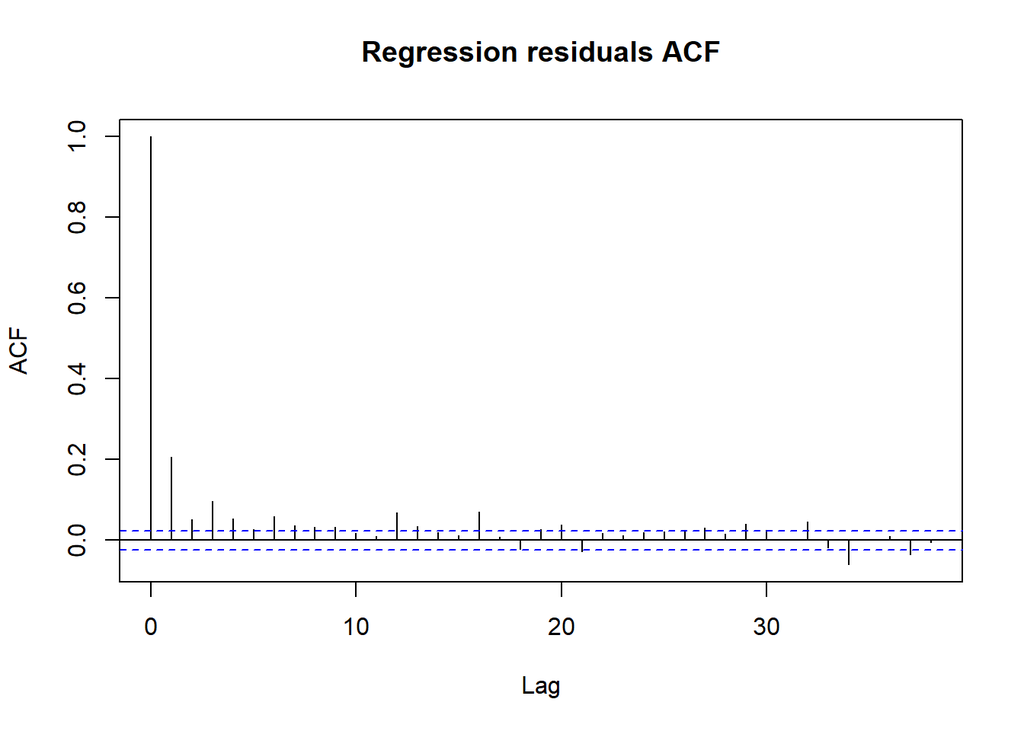

```r
autocorr<-acf(regression$residuals, main ='Regression residuals ACF'  )
```

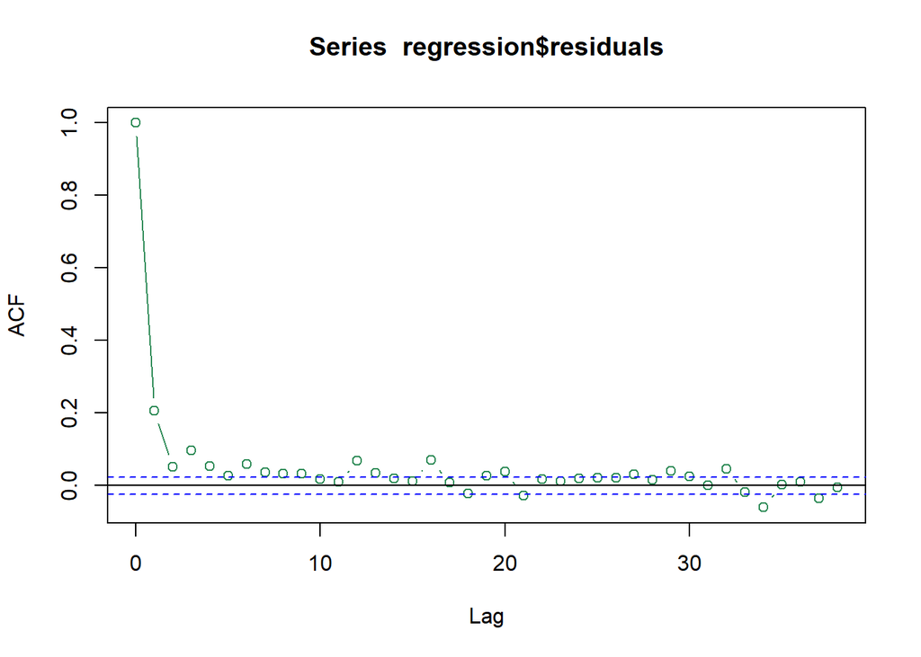

```r
plot(autocorr,type='b', col = 'seagreen')
```

After checking the results we see the particularly small outcome of the coefficients, however the fit is not entirely good since the AIC criterion differs enormously from 0 and the MSE is not too small in comparison to the values of the exercise

```r
resreg<-arima(regression$residuals,c(1,0,0))
summary(resreg)
```

```
##
## Call:
## arima(x = regression$residuals, order = c(1, 0, 0))
##
## Coefficients:
##          ar1  intercept
##       0.2061      0e+00
## s.e.  0.0115      1e-04
##
## sigma^2 estimated as 6.488e-05:  log likelihood = 24903.28,  aic = -49800.56
##
## Training set error measures:
##                        ME        RMSE         MAE      MPE     MAPE      MASE
## Training set 9.411138e-07 0.008054745 0.005044159 88.82005 199.3886 0.7917908
##                      ACF1
## Training set -0.002234885
```

## Part 5: GE stocks

```r
ww4 = 'https://www.mimuw.edu.pl/~noble/courses/TimeSeries/data/m-ge2608.txt'
GE <-read.csv(ww4,sep = '')
x0=data.frame(GE$rtn)
x1=data.frame(GE[-1,2])
x2=data.frame(x1[-1,])
x3=data.frame(x2[-1,])
x = data.frame(cbind(x0[1:991,],x1[1:991,],x2[1:991,]))
neuro<-nnet(x,x3[1:991,],size = 2,linout=TRUE)
summary(neuro)
```

```
## a 3-2-1 network with 11 weights
## options were - linear output units
##  b->h1 i1->h1 i2->h1 i3->h1
##  -2.04   3.26   1.03  -0.73
##  b->h2 i1->h2 i2->h2 i3->h2
## -13.70 -18.19 -15.90  11.96
##   b->o  h1->o  h2->o
##   0.03  -0.14   6.22
```

We get now the MSE from our neural network estimation. Using the prediction function. The MSE is large indeed so we conclude that the prediction estimation is bad.

```r
newdata_ = data.frame(cbind(x0[991:994,],x1[991:994,],x2[991:994,]))
pred = predict(neuro,newdata_)
mse <- sum((neuro$fitted.values-x0[1:991,])^2)
mse
```

```
## [1] 7.639337
```

```r
nntar1<-nnetar(ts(x0),p=3,size=2)
fore1 <-forecast(nntar1)
mse2 <- sum((nntar1$fitted[4:996]-x0[4:996,])^2)
mse2
```

```
## [1] 5.361714
```

```r
fore1
```

```
##      Point Forecast
## 997     0.004729535
## 998     0.013688062
## 999     0.011498638
## 1000    0.010812440
## 1001    0.010716732
## 1002    0.010747242
## 1003    0.010756295
## 1004    0.010757287
## 1005    0.010756870
## 1006    0.010756753
```

We are now going to plot the forecast but with a slight change since we are only going to use a part of the dataframe in the plot and prediction. The number of observed data is to big and at the time of plotting the predicted data seems too small when you do it with the entire mass of GE stocks returns 1926-2008. When plotting the results we see that the variation of the forecast seems a lot lower and that the prediction gets rather stuck and stable. This is probably due to the fact that the prediction is not too good, and also needs to be longer.

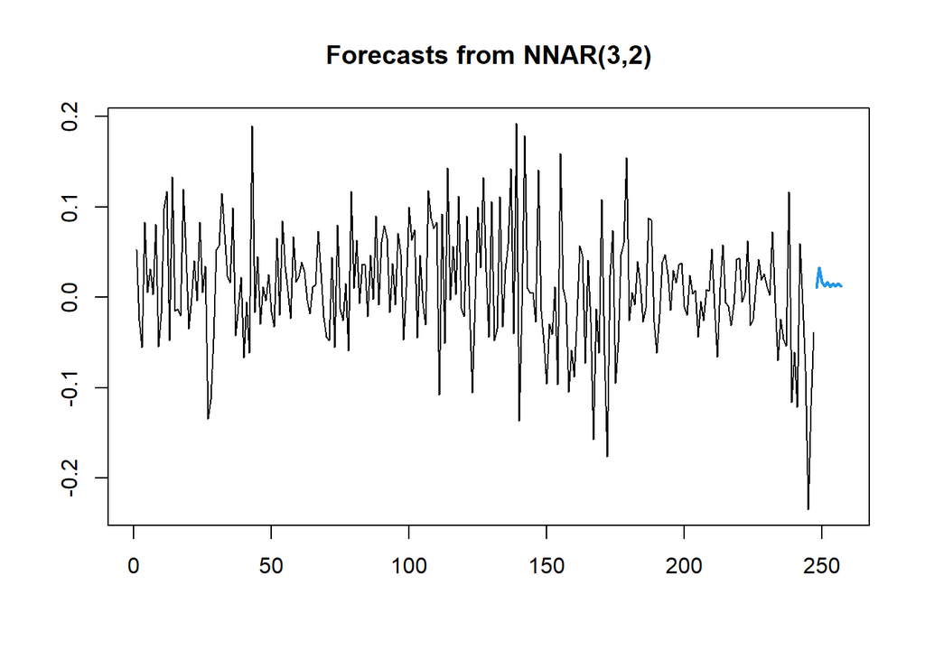

```r
nntar2<-nnetar(ts(x0[750:996,]),p=3,size=2)
fore2 <-forecast(nntar2)
plot(fore2)
```

```r
x4=data.frame(x3[-1,])
x5=data.frame(x4[-1,])
x6=data.frame(x5[-1,])
x<-cbind(x[1:990,],x4[1:990,],x5[1:990,])
neuro<-nnet(x[1:897,],x6[1:897,],size = 5,linout=TRUE)
summary(neuro)
```

```
## a 5-5-1 network with 36 weights
## options were - linear output units
##  b->h1 i1->h1 i2->h1 i3->h1 i4->h1 i5->h1
##  -5.32   2.91   2.92  -6.96   7.14   2.19
##  b->h2 i1->h2 i2->h2 i3->h2 i4->h2 i5->h2
##  -3.87   2.24  -2.48  -4.63   3.19  -0.10
##  b->h3 i1->h3 i2->h3 i3->h3 i4->h3 i5->h3
##  -3.66   2.11  -0.85  -6.84   4.37   3.55
##  b->h4 i1->h4 i2->h4 i3->h4 i4->h4 i5->h4
##  -9.78 -10.79  -9.33   2.12 -12.73  15.54
##  b->h5 i1->h5 i2->h5 i3->h5 i4->h5 i5->h5
##  -4.41  -2.56   3.35  -1.85  -3.15   5.31
##   b->o  h1->o  h2->o  h3->o  h4->o  h5->o
##   0.06   0.11  -2.68   1.06   3.66  -1.62
```

```r
prediction<-predict(neuro,x[987:990,],linout = FALSE)

result <- numeric(length(prediction))
for (i in 2:length(prediction)) {
  if (prediction[i] > prediction[i-1]) {
    result[i] <- 1
  } else {
    result[i] <- 0
  }
}
result
```

```
## [1] 0 1 1 0
```

## Part 6: US dollar-euro conversion

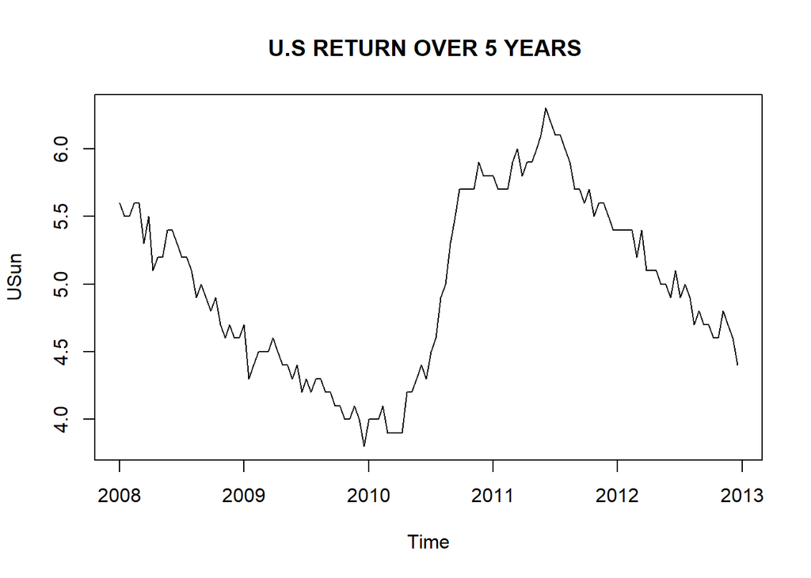

```r
ww5<- 'https://www.mimuw.edu.pl/~noble/courses/TimeSeries/data/USunemp.dat'
usreturn<-read.csv(ww5)
tsusreturn <- ts(usreturn, frequency = 26,start = 2008)

plot(tsusreturn,pch = 20, main = 'U.S RETURN OVER 5 YEARS ')
```

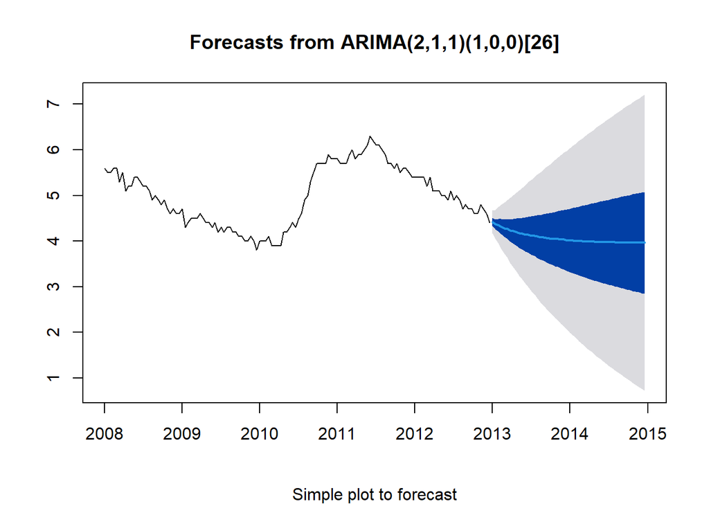

```r
autarima <- auto.arima(usreturn,max.p = 3,max.q =3 ,max.d = 3)
forearima<-  forecast(auto.arima(tsusreturn))
plot(forecast(auto.arima(tsusreturn),level=c(50,95)), sub = "Simple plot to forecast")
```

```r
summary(autarima)
```

```
## Series: usreturn
## ARIMA(0,1,2)
##
## Coefficients:
##           ma1     ma2
##       -0.1959  0.2761
## s.e.   0.0862  0.0904
##
## sigma^2 = 0.01663:  log likelihood = 82.11
## AIC=-158.22   AICc=-158.03   BIC=-149.64
##
## Training set error measures:
##                        ME      RMSE        MAE       MPE     MAPE      MASE
## Training set -0.008961229 0.1274522 0.09972549 -0.212978 2.034386 0.9895838
##                    ACF1
## Training set 0.01413554
```

```r
msearima <-sum((forearima$fitted-tsusreturn)^2)
msearima
```

```
## [1] 2.04408
```

We can also use the predict method and compare the results with our forecasting data. Lets take a look into it. We see that the forecast is not too elaborated, just a straight line that follows the previous plot, however the MSE return is just a little bit higher than our last MSE that we computed with the forecast function. Truly surprising if you think about it since this estimation seems a lot less accurate judging from the plot

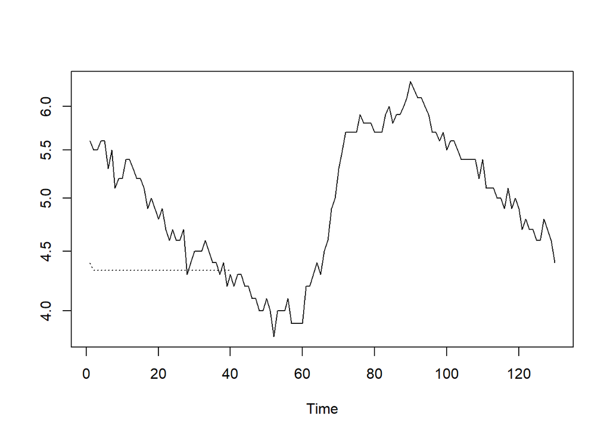

```r
pred <- predict(autarima,ci = 0.95,n.ahead=40)
ts.plot(ts(usreturn),ts(pred$pred), log = "y", lty = c(1,3))
```

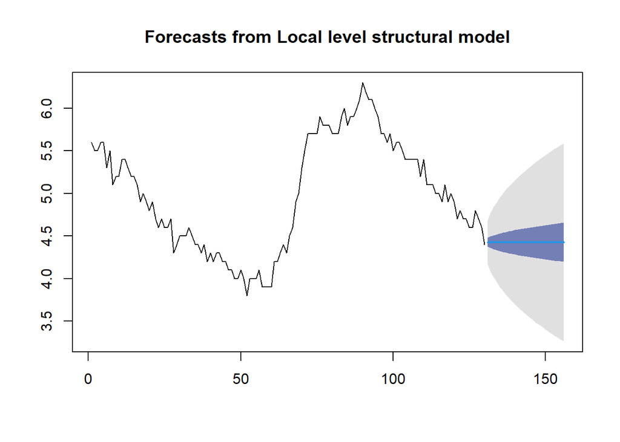

```r
fit <- StructTS(usreturn,type='level')
forespace<-forecast(fit)
plot(forecast(fit,h = 26,level = c(30,95), xlim = c(2013,2014)))
```

```r
msespace <-sum((forespace$fitted-ts(usreturn))^2)
msespace
```

```
## [1] 2.26619
```

Lets try now a function that has not been used in class for the second year of activity. We can try on prediction the next few values or predicting directly the second year taking into account the first as it is asked in the exam. We use it and check the performance via the mse. It is very satisfactory, we see that by plotting the results do not differ in more than 1 from the actual return of the US dollar for 2009 (year we are forecasting). The AIC criterion also returns a low value and the results are satisfactory. We set the box cox attribute to NULL in order to use it or not, however the result is more accurate. An MSE of 0.2 is extremely low, however is not comparable to the rest mainly because in the other cases we were using the entire data and here only year 1 and 2.

```r
fit <- tbats(tsusreturn[26:52],use.box.cox=NULL)
fit
```

```
## BATS(1, {0,0}, 1, -)
##
## Call: tbats(y = tsusreturn[26:52], use.box.cox = NULL)
##
## Parameters
##   Alpha: -0.0201
##   Beta: 0.05095642
##   Damping Parameter: 1
##
## Seed States:
##            [,1]
## [1,]  4.5803080
## [2,] -0.0102116
##
## Sigma: 0.09190848
## AIC: -31.90835
```

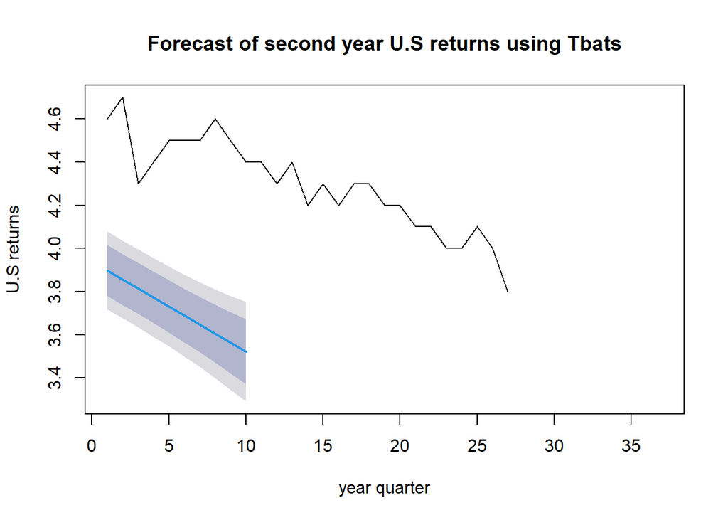

```r
plot(forecast(fit),main = 'Forecast of second year U.S returns using Tbats', ylab = 'U.S returns',xlab = 'year quarter')
```

```r
msetbats<-sum((fitted(fit)-usreturn[26:52,1])^2)
msetbats
```

```
## [1] 0.2280736
```

Lets do it now for the entire data and see the results with this new forecasting function from R. The result is not so satisfactory as before and computing the MSE we realized that the values are a little bit off The size of the forecast has to be taking into perspective specially when judging goodness of fit parameters that is why comparing it to previous predictions. It is in between the first and the second. Meaning the simple forecasting from an ARIMA process seems like the best options for now. We have to add that this function is based on an smoothed process so we just checked the validity of forecasting this piece of U.S returns using an smoothed process

```r
bats <- tbats(tsusreturn,use.box.cox=NULL)
bats
```

```
## BATS(1, {0,0}, 0.906, -)
##
## Call: tbats(y = tsusreturn, use.box.cox = NULL)
##
## Parameters
##   Alpha: 0.6855148
##   Beta: 0.1360618
##   Damping Parameter: 0.90572
##
## Seed States:
##               [,1]
## [1,]  5.6047770295
## [2,] -0.0001277221
##
## Sigma: 0.1262937
## AIC: 104.8018
```

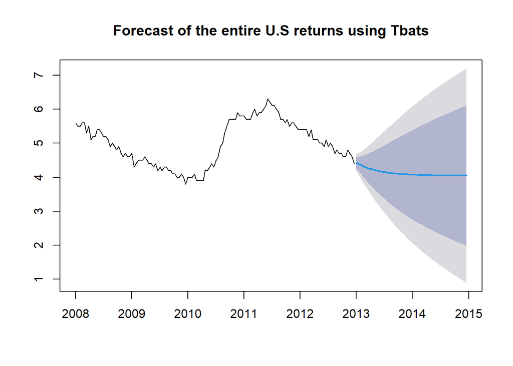

```r
plot(forecast(bats),main = 'Forecast of the entire U.S returns using Tbats')
```

```r
msebatss <- sum((fitted(bats)-tsusreturn)^2)
msebatss
```

```
## [1] 2.073514
```

```r
forecast_values <- list()

for (i in 26:52) {
  # Apply the nnetar forecasting function
  forecast_result <- forecast(nnetar(tsusreturn[1:i], p = 1, size = 2))


  # Store the forecast value in the list
  forecast_values[[i - 25]] <- forecast_result
}


extract_first_values <- function(forecast_list) {
  # Create an empty vector to store the first values
  first_values <- vector()

  # Iterate over each sublist
  for (i in 1:length(forecast_list)) {
    # Extract the first value from the sublist and store it in the vector
    first_values[i] <- forecast_list[[i]][1]
  }

  # Return the vector of first values
  return(first_values[27])
}
forecast_method<-extract_first_values(forecast_values)
forecast_method
```

```
## [[1]]
## Time Series:
## Start = 1
## End = 52
## Frequency = 1
##  [1] 5.6 5.5 5.5 5.6 5.6 5.3 5.5 5.1 5.2 5.2 5.4 5.4 5.3 5.2 5.2 5.1 4.9 5.0 4.9
## [20] 4.8 4.9 4.7 4.6 4.7 4.6 4.6 4.7 4.3 4.4 4.5 4.5 4.5 4.6 4.5 4.4 4.4 4.3 4.4
## [39] 4.2 4.3 4.2 4.3 4.3 4.2 4.2 4.1 4.1 4.0 4.0 4.1 4.0 3.8
```

```r
tsusreturn[1:52]
```

```
##  [1] 5.6 5.5 5.5 5.6 5.6 5.3 5.5 5.1 5.2 5.2 5.4 5.4 5.3 5.2 5.2 5.1 4.9 5.0 4.9
## [20] 4.8 4.9 4.7 4.6 4.7 4.6 4.6 4.7 4.3 4.4 4.5 4.5 4.5 4.6 4.5 4.4 4.4 4.3 4.4
## [39] 4.2 4.3 4.2 4.3 4.3 4.2 4.2 4.1 4.1 4.0 4.0 4.1 4.0 3.8
```